# Appendix S2. Model fitting and evaluation

This is version 0.18.11.27.

# 1 Requirements

All analyses require the [R software](https://cran.r-project.org/) (v3.4.3) for data retrieval, data processing, and summarizing model results, and the [JAGS software](http://mcmc-jags.sourceforge.net/) (v4.2.0) for Markov chain Monte Carlo (MCMC) simulation. Please note that some of the R code below may not work with older versions of JAGS due to some changes in the ways that arrays are handled.

We also need a few packages that are not included with the base installation of R, so we begin by installing them (if necessary) and then loading them.

```r
if(!require("here")) {
  install.packages("here")
  library("here")
}
if(!require("readr")) {
  install.packages("readr")
  library("readr")
}
if(!require("rjags")) {
  install.packages("rjags")
  library("rjags")
}
if(!require("loo")) {
  install.packages("loo")
  library("loo")
}
if(!require("ggplot2")) {
  install.packages("ggplot2")
  library("ggplot2")
}
## set directory locations
datadir <- here("data")
jagsdir <- here("jags")
analdir <- here("analysis")
savedir <- here("analysis/cache")
```

We also need a couple of helper functions.

```r
## better round
Re2prec <- function(x, map = "round", prec = 1) {
  ## 'map' can be "round", "floor", or "ceiling"
  ## 'prec' is nearest value (eg, 0.1 means to nearest tenth; 1 gives normal behavior)
  if(prec<=0) { stop("\"prec\" cannot be less than or equal to 0") }
  do.call(map,list(x/prec))*prec
}

## wrapper function to fit JAGS models & rearrange output
fit_jags <- function(model, data, params, inits, ctrl, dir = jagsdir) {
  jm <- jags.model(file.path(jagsdir, model),
                   data,
                   inits,
                   ctrl$chains,
                   ctrl$burn,
                   quiet = TRUE)
  return(coda.samples(jm, params, ctrl$length, ctrl$thin))
}
```

# 2 User inputs

We begin by supplying values for the following parameters, which we need for model fitting and evaluation.

```r
## first & last years of fish data
yr_frst <- 1978
yr_last <- 2018

## min & max adult age classes
age_min <- 3
age_max <- 8
## years (if any) of age-comp to skip; see below
age_skip <- 0

## number of years for run forecasts
n_fore <- 0

## upper threshold for Gelman & Rubin's potential scale reduction factor (Rhat).
Rhat_thresh <- 1.1
```

Next we specify the names of three necessary data files containing the following information:

1. observed total number of adult spawners (escapement) by year;
2. observed age composition of adult spawners by year;
3. observed total harvest by year;

```r
## 1. file with escapement data
## [n_yrs x 2] matrix of obs counts; 1st col is calendar yr
fn_esc <- "skagit_sthd_esc.csv"

## 2. file with age comp data
## [n_yrs x (1+A)]; 1st col is calendar yr
fn_age <- "skagit_sthd_age.csv"

## 3. file with harvest data
## [n_yrs x 2] matrix of obs catch; 1st col is calendar yr
fn_harv <- "skagit_sthd_catch.csv"
```

# 3 Loading the fish data

Here we load in the first three data files and do some simple calculations and manipulations. First the spawner data:

```r
## escapement
dat_esc <- read_csv(file.path(datadir, fn_esc))
## years of data
dat_yrs <- dat_esc$year
## number of years of data
n_yrs <- length(dat_yrs)
## log of escapement
ln_dat_esc <- c(log(dat_esc$escapement),rep(NA,n_fore))
```

Next the age composition data:

```r
## age comp data
dat_age <- read_csv(file.path(datadir, fn_age))
## drop year col & first (age_min + age_skip) rows
dat_age <- dat_age[-(1:(age_min+age_skip)),-1]
## num of age classes
A <- age_max - age_min + 1
## add row(s) of NA's for forecast years
if(n_fore > 0) {
  dat_age <- rbind(dat_age,
                   matrix(0, n_fore, A,
                          dimnames = list(n_yrs+seq(n_fore),colnames(dat_age))))
}
## total num of age obs by cal yr
dat_age[,"sum"] <- apply(dat_age, 1, sum)
## row indices for any years with no obs age comp
idx_NA_yrs <- which(dat_age$sum<A, TRUE)
## replace 0's in yrs w/o any obs with NA's
dat_age[idx_NA_yrs,(1:A)] <- NA
## change total in yrs w/o any obs from 0 to A to help dmulti()
dat_age[idx_NA_yrs,"sum"] <- A
## convert class
dat_age <- as.matrix(dat_age)
```

And then the harvest data:

```r
## harvest
dat_harv <- read_csv(file.path(datadir, fn_harv))
## drop year col & first age_max rows
dat_harv <- c(dat_harv$catch, rep(0,n_fore))
```

# 4 Loading the covariates

Our analysis investigates the effects of 4 covariates on the population’s instrinic growth rate:

1. Maximum river discharge in winter;
2. Minimum river discharge in summer;
3. North Pacific Gyre Oscillation;
4. Releases of hatchery-born juveniles.

All of the covariates are contained in the file `/data/skagit_sthd_covars.csv`. We will load and then standardize them to have zero-mean and unit-variance.

```r
## covariate(s)
dat_cvrs <- read_csv(file.path(datadir, "skagit_sthd_covars.csv"))
## drop year col
dat_cvrs <- dat_cvrs[,-1]
## transform the covariates to z-scores
scl_cvrs <- as.matrix(scale(dat_cvrs))
## total number of covariates
n_cov <- dim(scl_cvrs)[2]
```

# 5 Specifying models in JAGS

Now we can specify the various models in JAGS. We fit a total of 4 different models, which we outline below, based on the 2 different process models with and without and covariates.

## 5.1 Ricker with AR(1)

```r
cat("

model {

  ##--------
  ## PRIORS
  ##--------
  ## alpha = exp(a) = intrinsic productivity
  alpha ~ dnorm(0,0.01) T(0,);
  mu_Rkr_a <- log(alpha);
  E_Rkr_a <- mu_Rkr_a + sigma_r/(2 - 2*phi^2);

  ## strength of dens depend
  beta_inv ~ dnorm(0, 1e-9) T(0,);
  beta <- 1/beta_inv;

  ## AR(1) coef for proc errors
  phi ~ dunif(-0.999,0.999);

  ## process variance for recruits model
  sigma_r ~ dnorm(0, 2e-2) T(0,);
  tau_r <- 1/sigma_r;

  ## innovation in first year
  innov_1 ~ dnorm(0,tau_r*(1-phi*phi));

  ## obs variance for spawners
  tau_s <- 1/sigma_s;
  sigma_s ~ dnorm(0, 0.001) T(0,);

  ## maturity schedule
  ## unif vec for Dirch prior
  theta <- c(1,10,10,5,1,1)
  ## hyper-mean for maturity
  pi_eta ~ ddirch(theta);
  ## hyper-prec for maturity
  pi_tau ~ dnorm(0, 0.01) T(0,);
  for(t in 1:(n_yrs-age_min+n_fore)) { pi_vec[t,1:A] ~ ddirch(pi_eta*pi_tau) }

  ## unprojectable early recruits;
  ## hyper mean across all popns
  Rec_mu ~ dnorm(0,0.001);
  ## hyper SD across all popns
  Rec_sig ~ dunif(0,100);
  ## precision across all popns
  Rec_tau <- pow(Rec_sig,-2);
  ## multipliers for unobservable total runs
    ttl_run_mu ~ dunif(1,5);
    ttl_run_tau ~ dunif(1,20);

  ## get total cal yr returns for first age_min yrs
  for(i in 1:(age_min+age_skip)) {
        ln_tot_Run[i] ~ dnorm(ttl_run_mu*Rec_mu,Rec_tau/ttl_run_tau);
        tot_Run[i] <- exp(ln_tot_Run[i]);
  }

  ## estimated harvest rate
  for(t in 1:(n_yrs+n_fore)) { h_rate[t] ~ dunif(0,1) }

  ##------------
  ## LIKELIHOOD
  ##------------
  ## 1st brood yr requires different innovation
  ## predicted recruits in BY t
  ln_Rkr_a[1] <- mu_Rkr_a;
  E_ln_Rec[1] <- ln_Rkr_a[1] + ln_Sp[1] - beta*Sp[1] + phi*innov_1;
  tot_ln_Rec[1] ~ dnorm(E_ln_Rec[1],tau_r);
  res_ln_Rec[1] <- tot_ln_Rec[1] - E_ln_Rec[1];
  ## median of total recruits
  tot_Rec[1] <- exp(tot_ln_Rec[1]);

  ## R/S
  ln_RS[1] <- tot_ln_Rec[1] - ln_Sp[1];

  ## brood-yr recruits by age
  for(a in 1:A) {
    Rec[1,a] <- tot_Rec[1] * pi_vec[1,a];
  }

  ## brood years 2:(n_yrs-age_min)
  for(t in 2:(n_yrs-age_min+n_fore)) {
    ## predicted recruits in BY t
    ln_Rkr_a[t] <- mu_Rkr_a;
    E_ln_Rec[t] <- ln_Rkr_a[t] + ln_Sp[t] - beta*Sp[t] + phi*res_ln_Rec[t-1];
    tot_ln_Rec[t] ~ dnorm(E_ln_Rec[t],tau_r);
    res_ln_Rec[t] <- tot_ln_Rec[t] - E_ln_Rec[t];
    ## median of total recruits
    tot_Rec[t] <- exp(tot_ln_Rec[t]);
    ## R/S
    ln_RS[t] <- tot_ln_Rec[t] - ln_Sp[t];
    ## brood-yr recruits by age
    for(a in 1:A) {
      Rec[t,a] <- tot_Rec[t] * pi_vec[t,a];
    }
  } ## end t loop over year

  ## get predicted calendar year returns by age
  ## matrix Run has dim [(n_yrs-age_min) x A]
  ## step 1: incomplete early broods
  ## first cal yr of this grp is first brood yr + age_min + age_skip
  for(i in 1:(age_max-age_min-age_skip)) {
    ## projected recruits
    for(a in 1:(i+age_skip)) {
      Run[i,a] <- Rec[(age_skip+i)-a+1,a];
    }
    ## imputed recruits
    for(a in (i+1+age_skip):A) {
      lnRec[i,a] ~ dnorm(Rec_mu,Rec_tau);
      Run[i,a] <- exp(lnRec[i,a]);
    }
    ## total run size
    tot_Run[i+age_min+age_skip] <- sum(Run[i,1:A]);
    ## predicted age-prop vec for multinom
    for(a in 1:A) {
      age_v[i,a] <- Run[i,a] / tot_Run[i+age_min];
    }
    ## multinomial for age comp
    dat_age[i,1:A] ~ dmulti(age_v[i,1:A],dat_age[i,A+1]);
    lp_age[i] <- logdensity.multi(dat_age[i,1:A],age_v[i,1:A],dat_age[i,A+1]);
  }

  ## step 2: info from complete broods
  ## first cal yr of this grp is first brood yr + age_max
  for(i in (A-age_skip):(n_yrs-age_min-age_skip+n_fore)) {
    for(a in 1:A) {
      Run[i,a] <- Rec[(age_skip+i)-a+1,a];
    }
    ## total run size
    tot_Run[i+age_min+age_skip] <- sum(Run[i,1:A]);
    ## predicted age-prop vec for multinom
    for(a in 1:A) {
      age_v[i,a] <- Run[i,a] / tot_Run[i+age_min];
    }
    ## multinomial for age comp
    dat_age[i,1:A] ~ dmulti(age_v[i,1:A],dat_age[i,A+1]);
    lp_age[i] <- logdensity.multi(dat_age[i,1:A],age_v[i,1:A],dat_age[i,A+1]);
  }

  ## get predicted calendar year spawners
  ## first cal yr is first brood yr
  for(t in 1:(n_yrs+n_fore)) {
    ## obs model for spawners
    # Sp[t] <- max(10,tot_Run[t] - dat_harv[t]);
    est_harv[t] = h_rate[t] * tot_Run[t];
    dat_harv[t] ~ dlnorm(log(est_harv[t]), 20);
    Sp[t] = tot_Run[t] - est_harv[t];
    ln_Sp[t] <- log(Sp[t]);
    ln_dat_esc[t] ~ dnorm(ln_Sp[t], tau_s);
    lp_esc[t] <- logdensity.norm(ln_dat_esc[t],ln_Sp[t], tau_s);
  }

} ## end model description

", file=file.path(jagsdir, "IPM_RK_AR.txt"))
```

## 5.2 Ricker with all covars & AR(1)

```r
cat("

model {

  ##--------
  ## PRIORS
  ##--------
  ## alpha = exp(a) = intrinsic productivity
  alpha ~ dnorm(0,0.01) T(0,);
  mu_Rkr_a <- log(alpha);
  E_Rkr_a <- mu_Rkr_a + sigma_r/(2 - 2*phi^2);

  ## strength of dens depend
  beta_inv ~ dnorm(0, 1e-9) T(0,);
  beta <- 1/beta_inv;

  ## covariate effects
  for(i in 1:n_cov) { gamma[i] ~ dnorm(0,0.01) }

  ## AR(1) coef for proc errors
  # phi ~ dunif(-0.999,0.999);
  phi <- 0;

  ## process variance for recruits model
  sigma_r ~ dnorm(0, 2e-2) T(0,);
  tau_r <- 1/sigma_r;

  ## innovation in first year
  innov_1 ~ dnorm(0,tau_r*(1-phi*phi));

  ## obs variance for spawners
  tau_s <- 1/sigma_s;
  sigma_s ~ dnorm(0, 0.001) T(0,);

  ## maturity schedule
  ## unif vec for Dirch prior
  theta <- c(1,10,10,5,1,1)
  ## hyper-mean for maturity
  pi_eta ~ ddirch(theta);
  ## hyper-prec for maturity
  pi_tau ~ dnorm(0, 0.01) T(0,);
  for(t in 1:(n_yrs-age_min+n_fore)) { pi_vec[t,1:A] ~ ddirch(pi_eta*pi_tau) }

  ## unprojectable early recruits;
  ## hyper mean across all popns
  Rec_mu ~ dnorm(0,0.001);
  ## hyper SD across all popns
  Rec_sig ~ dunif(0,100);
  ## precision across all popns
  Rec_tau <- pow(Rec_sig,-2);
  ## multipliers for unobservable total runs
    ttl_run_mu ~ dunif(1,5);
    ttl_run_tau ~ dunif(1,20);

  ## get total cal yr returns for first age_min yrs
  for(i in 1:(age_min+age_skip)) {
        ln_tot_Run[i] ~ dnorm(ttl_run_mu*Rec_mu,Rec_tau/ttl_run_tau);
        tot_Run[i] <- exp(ln_tot_Run[i]);
  }

  ## estimated harvest rate
  for(t in 1:(n_yrs+n_fore)) { h_rate[t] ~ dunif(0,1) }

  ##------------
  ## LIKELIHOOD
  ##------------
  ## 1st brood yr requires different innovation
  ## predicted recruits in BY t
  covar[1] <- inprod(gamma,mod_cvrs[1,]);
  ln_Rkr_a[1] <- mu_Rkr_a + covar[1];
  E_ln_Rec[1] <- ln_Rkr_a[1] + ln_Sp[1] - beta*Sp[1] + phi*innov_1;
  tot_ln_Rec[1] ~ dnorm(E_ln_Rec[1],tau_r);
  res_ln_Rec[1] <- tot_ln_Rec[1] - E_ln_Rec[1];
  ## median of total recruits
  tot_Rec[1] <- exp(tot_ln_Rec[1]);

  ## R/S
  ln_RS[1] <- tot_ln_Rec[1] - ln_Sp[1];

  ## brood-yr recruits by age
  for(a in 1:A) {
    Rec[1,a] <- tot_Rec[1] * pi_vec[1,a];
  }

  ## brood years 2:(n_yrs-age_min)
  for(t in 2:(n_yrs-age_min+n_fore)) {
    ## predicted recruits in BY t
    covar[t] <- inprod(gamma, mod_cvrs[t,]);
    ln_Rkr_a[t] <- mu_Rkr_a + covar[t];
    E_ln_Rec[t] <- ln_Rkr_a[t] + ln_Sp[t] - beta*Sp[t] + phi*res_ln_Rec[t-1];
    tot_ln_Rec[t] ~ dnorm(E_ln_Rec[t],tau_r);
    res_ln_Rec[t] <- tot_ln_Rec[t] - E_ln_Rec[t];
    ## median of total recruits
    tot_Rec[t] <- exp(tot_ln_Rec[t]);
    ## R/S
    ln_RS[t] <- tot_ln_Rec[t] - ln_Sp[t];
    ## brood-yr recruits by age
    for(a in 1:A) {
      Rec[t,a] <- tot_Rec[t] * pi_vec[t,a];
    }
  } ## end t loop over year

  ## get predicted calendar year returns by age
  ## matrix Run has dim [(n_yrs-age_min) x A]
  ## step 1: incomplete early broods
  ## first cal yr of this grp is first brood yr + age_min + age_skip
  for(i in 1:(age_max-age_min-age_skip)) {
    ## projected recruits
    for(a in 1:(i+age_skip)) {
      Run[i,a] <- Rec[(age_skip+i)-a+1,a];
    }
    ## imputed recruits
    for(a in (i+1+age_skip):A) {
      lnRec[i,a] ~ dnorm(Rec_mu,Rec_tau);
      Run[i,a] <- exp(lnRec[i,a]);
    }
    ## total run size
    tot_Run[i+age_min+age_skip] <- sum(Run[i,1:A]);
    ## predicted age-prop vec for multinom
    for(a in 1:A) {
      age_v[i,a] <- Run[i,a] / tot_Run[i+age_min];
    }
    ## multinomial for age comp
    dat_age[i,1:A] ~ dmulti(age_v[i,1:A],dat_age[i,A+1]);
    lp_age[i] <- logdensity.multi(dat_age[i,1:A],age_v[i,1:A],dat_age[i,A+1]);
  }

  ## step 2: info from complete broods
  ## first cal yr of this grp is first brood yr + age_max
  for(i in (A-age_skip):(n_yrs-age_min-age_skip+n_fore)) {
    for(a in 1:A) {
      Run[i,a] <- Rec[(age_skip+i)-a+1,a];
    }
    ## total run size
    tot_Run[i+age_min+age_skip] <- sum(Run[i,1:A]);
    ## predicted age-prop vec for multinom
    for(a in 1:A) {
      age_v[i,a] <- Run[i,a] / tot_Run[i+age_min];
    }
    ## multinomial for age comp
    dat_age[i,1:A] ~ dmulti(age_v[i,1:A],dat_age[i,A+1]);
    lp_age[i] <- logdensity.multi(dat_age[i,1:A],age_v[i,1:A],dat_age[i,A+1]);
  }

  ## get predicted calendar year spawners
  ## first cal yr is first brood yr
  for(t in 1:(n_yrs+n_fore)) {
    ## obs model for spawners
    # Sp[t] <- max(10,tot_Run[t] - dat_harv[t]);
    est_harv[t] = h_rate[t] * tot_Run[t];
    dat_harv[t] ~ dlnorm(log(est_harv[t]), 20);
    Sp[t] = tot_Run[t] - est_harv[t];
    ln_Sp[t] <- log(Sp[t]);
    ln_dat_esc[t] ~ dnorm(ln_Sp[t], tau_s);
    lp_esc[t] <- logdensity.norm(ln_dat_esc[t],ln_Sp[t], tau_s);
  }

} ## end model description

", file=file.path(jagsdir, "IPM_RK_cov_AR.txt"))
```

## 5.3 Beverton-Holt with AR(1)

```r
cat("

model {

  ##--------
  ## PRIORS
  ##--------
  ## alpha = exp(a) = intrinsic productivity
  alpha ~ dnorm(0,0.001) T(0,);
  mu_BH_a <- log(alpha);
  E_BH_a <- mu_BH_a + sigma_r/(2 - 2*phi^2);

  ## strength of dens depend
  beta_inv ~ dnorm(0, 1e-9) T(0,);
  beta <- 1/beta_inv;

  ## AR(1) coef for proc errors
  phi ~ dunif(-0.999,0.999);

  ## process variance for recruits model
  sigma_r ~ dnorm(0, 2e-2) T(0,);
  tau_r <- 1/sigma_r;

  ## innovation in first year
  innov_1 ~ dnorm(0,tau_r*(1-phi*phi));

  ## obs variance for spawners
  tau_s <- 1/sigma_s;
  sigma_s ~ dnorm(0, 0.001) T(0,);

  ## unprojectable early recruits;
  ## hyper mean across all popns
  Rec_mu ~ dnorm(0,0.001);
  ## hyper SD across all popns
  Rec_sig ~ dunif(0,100);
  ## precision across all popns
  Rec_tau <- pow(Rec_sig,-2);
  ## multipliers for unobservable total runs
    ttl_run_mu ~ dunif(1,5);
    ttl_run_tau ~ dunif(1,20);

  ## get total cal yr returns for first age_min yrs
  for(i in 1:(age_min+age_skip)) {
        ln_tot_Run[i] ~ dnorm(ttl_run_mu*Rec_mu,Rec_tau/ttl_run_tau);
        tot_Run[i] <- exp(ln_tot_Run[i]);
  }

  ## maturity schedule
  ## unif vec for Dirch prior
  theta <- c(1,10,10,5,1,1)
  ## hyper-mean for maturity
  pi_eta ~ ddirch(theta);
  ## hyper-prec for maturity
  pi_tau ~ dnorm(0, 0.01) T(0,);
  for(t in 1:(n_yrs-age_min+n_fore)) { pi_vec[t,1:A] ~ ddirch(pi_eta*pi_tau) }

  ## estimated harvest rate
  for(t in 1:(n_yrs+n_fore)) { h_rate[t] ~ dunif(0,1) }

  ##------------
  ## LIKELIHOOD
  ##------------
  ## 1st brood yr requires different innovation
  ## predicted recruits in BY t
  ln_BH_a[1] <- mu_BH_a;
  E_ln_Rec[1] <- ln_BH_a[1] + ln_Sp[1] - log(1 + beta*Sp[1]) + phi*innov_1;
  tot_ln_Rec[1] ~ dnorm(E_ln_Rec[1],tau_r);
  res_ln_Rec[1] <- tot_ln_Rec[1] - E_ln_Rec[1];
  ## median of total recruits
  tot_Rec[1] <- exp(tot_ln_Rec[1]);

  ## R/S
  ln_RS[1] <- tot_ln_Rec[1] - ln_Sp[1];

  ## brood-yr recruits by age
  for(a in 1:A) {
    Rec[1,a] <- tot_Rec[1] * pi_vec[1,a];
  }

  ## brood years 2:(n_yrs-age_min)
  for(t in 2:(n_yrs-age_min+n_fore)) {
    ## predicted recruits in BY t
    ln_BH_a[t] <- mu_BH_a;
    E_ln_Rec[t] <- ln_BH_a[t] + ln_Sp[t] - log(1 + beta*Sp[t]) + phi*res_ln_Rec[t-1];
    tot_ln_Rec[t] ~ dnorm(E_ln_Rec[t],tau_r);
    res_ln_Rec[t] <- tot_ln_Rec[t] - E_ln_Rec[t];
    ## median of total recruits
    tot_Rec[t] <- exp(tot_ln_Rec[t]);
    ## R/S
    ln_RS[t] <- tot_ln_Rec[t] - ln_Sp[t];
    ## brood-yr recruits by age
    for(a in 1:A) {
      Rec[t,a] <- tot_Rec[t] * pi_vec[t,a];
    }
  } ## end t loop over year

  ## get predicted calendar year returns by age
  ## matrix Run has dim [(n_yrs-age_min) x A]
  ## step 1: incomplete early broods
  ## first cal yr of this grp is first brood yr + age_min + age_skip
  for(i in 1:(age_max-age_min-age_skip)) {
    ## projected recruits
    for(a in 1:(i+age_skip)) {
      Run[i,a] <- Rec[(age_skip+i)-a+1,a];
    }
    ## imputed recruits
    for(a in (i+1+age_skip):A) {
      lnRec[i,a] ~ dnorm(Rec_mu,Rec_tau);
      Run[i,a] <- exp(lnRec[i,a]);
    }
    ## total run size
    tot_Run[i+age_min+age_skip] <- sum(Run[i,1:A]);
    ## predicted age-prop vec for multinom
    for(a in 1:A) {
      age_v[i,a] <- Run[i,a] / tot_Run[i+age_min];
    }
    ## multinomial for age comp
    dat_age[i,1:A] ~ dmulti(age_v[i,1:A],dat_age[i,A+1]);
    lp_age[i] <- logdensity.multi(dat_age[i,1:A],age_v[i,1:A],dat_age[i,A+1]);
  }

  ## step 2: info from complete broods
  ## first cal yr of this grp is first brood yr + age_max
  for(i in (A-age_skip):(n_yrs-age_min-age_skip+n_fore)) {
    for(a in 1:A) {
      Run[i,a] <- Rec[(age_skip+i)-a+1,a];
    }
    ## total run size
    tot_Run[i+age_min+age_skip] <- sum(Run[i,1:A]);
    ## predicted age-prop vec for multinom
    for(a in 1:A) {
      age_v[i,a] <- Run[i,a] / tot_Run[i+age_min];
    }
    ## multinomial for age comp
    dat_age[i,1:A] ~ dmulti(age_v[i,1:A],dat_age[i,A+1]);
    lp_age[i] <- logdensity.multi(dat_age[i,1:A],age_v[i,1:A],dat_age[i,A+1]);
  }

  ## get predicted calendar year spawners
  ## first cal yr is first brood yr
  for(t in 1:(n_yrs+n_fore)) {
    ## obs model for spawners
    # Sp[t] <- max(10,tot_Run[t] - dat_harv[t]);
    est_harv[t] = h_rate[t] * tot_Run[t];
    dat_harv[t] ~ dlnorm(log(est_harv[t]), 20);
    Sp[t] = tot_Run[t] - est_harv[t];
    ln_Sp[t] <- log(Sp[t]);
    ln_dat_esc[t] ~ dnorm(ln_Sp[t], tau_s);
    lp_esc[t] <- logdensity.norm(ln_dat_esc[t],ln_Sp[t], tau_s);
  }

} ## end model description

", file=file.path(jagsdir, "IPM_BH_AR.txt"))
```

## 5.4 Beverton-Holt with all covars & AR(1)

```r
cat("

model {

  ##--------
  ## PRIORS
  ##--------
  ## alpha = intrinsic productivity
  alpha ~ dnorm(0,0.001) T(0,);
  mu_BH_a <- log(alpha);
  E_BH_a <- mu_BH_a + sigma_r/(2 - 2*phi^2);

  ## strength of dens depend
  beta_inv ~ dnorm(0, 1e-9) T(0,);
  beta <- 1/beta_inv;

  ## covariate effects
  for(i in 1:n_cov) { gamma[i] ~ dnorm(0,0.01) }

  ## AR(1) coef for proc errors
  # phi ~ dunif(-0.999,0.999);
  phi <- 0;

  ## innovation in first year
  innov_1 ~ dnorm(0,tau_r*(1-phi*phi));

  ## process variance for recruits model
  sigma_r ~ dnorm(0, 2e-2) T(0,);
  tau_r <- 1/sigma_r;

  ## obs variance for spawners
  tau_s <- 1/sigma_s;
  sigma_s ~ dnorm(0, 0.001) T(0,);

  ## unprojectable early recruits;
  ## hyper mean across all popns
  Rec_mu ~ dnorm(0,0.001);
  ## hyper SD across all popns
  Rec_sig ~ dunif(0,100);
  ## precision across all popns
  Rec_tau <- pow(Rec_sig,-2);
  ## multipliers for unobservable total runs
    ttl_run_mu ~ dunif(1,5);
    ttl_run_tau ~ dunif(1,20);

  ## get total cal yr returns for first age_min yrs
  for(i in 1:(age_min+age_skip)) {
        ln_tot_Run[i] ~ dnorm(ttl_run_mu*Rec_mu,Rec_tau/ttl_run_tau);
        tot_Run[i] <- exp(ln_tot_Run[i]);
  }

  ## maturity schedule
  ## unif vec for Dirch prior
  theta <- c(1,10,10,5,1,1)
  ## hyper-mean for maturity
  pi_eta ~ ddirch(theta);
  ## hyper-prec for maturity
  pi_tau ~ dnorm(0, 0.01) T(0,);
  for(t in 1:(n_yrs-age_min+n_fore)) { pi_vec[t,1:A] ~ ddirch(pi_eta*pi_tau) }

  ## estimated harvest rate
  for(t in 1:(n_yrs+n_fore)) { h_rate[t] ~ dunif(0,1) }

  ##------------
  ## LIKELIHOOD
  ##------------
  ## predicted recruits in BY t
  covar[1] <- inprod(gamma,mod_cvrs[1,]);
  ln_BH_a[1] <- mu_BH_a + covar[1];
  E_ln_Rec[1] <- ln_BH_a[1] + ln_Sp[1] - log(1 + beta*Sp[1]) + phi*innov_1;
  tot_ln_Rec[1] ~ dnorm(E_ln_Rec[1],tau_r);
  res_ln_Rec[1] <- tot_ln_Rec[1] - E_ln_Rec[1];
  ## median of total recruits
  tot_Rec[1] <- exp(tot_ln_Rec[1]);

  ## R/S
  ln_RS[1] <- tot_ln_Rec[1] - ln_Sp[1];

  ## brood-yr recruits by age
  for(a in 1:A) {
    Rec[1,a] <- tot_Rec[1] * pi_vec[1,a];
  }

  ## brood years 2:(n_yrs-age_min)
  for(t in 2:(n_yrs-age_min+n_fore)) {
    ## predicted recruits in BY t
    covar[t] <- inprod(gamma, mod_cvrs[t,]);
    ln_BH_a[t] <- mu_BH_a + covar[t];
    E_ln_Rec[t] <- ln_BH_a[t] + ln_Sp[t] - log(1 + beta*Sp[t]) + phi*res_ln_Rec[t-1];
    tot_ln_Rec[t] ~ dnorm(E_ln_Rec[t],tau_r);
    res_ln_Rec[t] <- tot_ln_Rec[t] - E_ln_Rec[t];
    ## median of total recruits
    tot_Rec[t] <- exp(tot_ln_Rec[t]);
    ## R/S
    ln_RS[t] <- tot_ln_Rec[t] - ln_Sp[t];
    ## brood-yr recruits by age
    for(a in 1:A) {
      Rec[t,a] <- tot_Rec[t] * pi_vec[t,a];
    }
  } ## end t loop over year

  ## get predicted calendar year returns by age
  ## matrix Run has dim [(n_yrs-age_min) x A]
  ## step 1: incomplete early broods
  ## first cal yr of this grp is first brood yr + age_min + age_skip
  for(i in 1:(age_max-age_min-age_skip)) {
    ## projected recruits
    for(a in 1:(i+age_skip)) {
      Run[i,a] <- Rec[(age_skip+i)-a+1,a];
    }
    ## imputed recruits
    for(a in (i+1+age_skip):A) {
      lnRec[i,a] ~ dnorm(Rec_mu,Rec_tau);
      Run[i,a] <- exp(lnRec[i,a]);
    }
    ## total run size
    tot_Run[i+age_min+age_skip] <- sum(Run[i,1:A]);
    ## predicted age-prop vec for multinom
    for(a in 1:A) {
      age_v[i,a] <- Run[i,a] / tot_Run[i+age_min];
    }
    ## multinomial for age comp
    dat_age[i,1:A] ~ dmulti(age_v[i,1:A],dat_age[i,A+1]);
    lp_age[i] <- logdensity.multi(dat_age[i,1:A],age_v[i,1:A],dat_age[i,A+1]);
  }

  ## step 2: info from complete broods
  ## first cal yr of this grp is first brood yr + age_max
  for(i in (A-age_skip):(n_yrs-age_min-age_skip+n_fore)) {
    for(a in 1:A) {
      Run[i,a] <- Rec[(age_skip+i)-a+1,a];
    }
    ## total run size
    tot_Run[i+age_min+age_skip] <- sum(Run[i,1:A]);
    ## predicted age-prop vec for multinom
    for(a in 1:A) {
      age_v[i,a] <- Run[i,a] / tot_Run[i+age_min];
    }
    ## multinomial for age comp
    dat_age[i,1:A] ~ dmulti(age_v[i,1:A],dat_age[i,A+1]);
    lp_age[i] <- logdensity.multi(dat_age[i,1:A],age_v[i,1:A],dat_age[i,A+1]);
  }

  ## get predicted calendar year spawners
  ## first cal yr is first brood yr
  for(t in 1:(n_yrs+n_fore)) {
    ## obs model for spawners
    # Sp[t] <- max(10,tot_Run[t] - dat_harv[t]);
    est_harv[t] = h_rate[t] * tot_Run[t];
    dat_harv[t] ~ dlnorm(log(est_harv[t]), 20);
    Sp[t] = tot_Run[t] - est_harv[t];
    ln_Sp[t] <- log(Sp[t]);
    ln_dat_esc[t] ~ dnorm(ln_Sp[t], tau_s);
    lp_esc[t] <- logdensity.norm(ln_dat_esc[t],ln_Sp[t], tau_s);
  }

} ## end model description

", file=file.path(jagsdir, "IPM_BH_cov_AR.txt"))
```

# 6 Fitting the models

Before fitting the model in JAGS, we need to specify:

1. the data and indices that go into the model;
2. the model parameters and states that we want JAGS to return;
3. the MCMC control parameters.

```r
## 1. Data to pass to JAGS
dat_jags <- list(dat_age = dat_age,
                 ln_dat_esc = ln_dat_esc,
                 dat_harv = dat_harv,
                 A = A,
                 age_min = age_min,
                 age_max = age_max,
                 age_skip = age_skip,
                 n_yrs = n_yrs,
                 n_fore = n_fore)

## 2. Model params/states for JAGS to return
##    These are specific to the process model,
##    so we define them in 'par_jags' below.

## 3. MCMC control params
mcmc_ctrl <- list(
  chains = 4,
  length = 5e5,
  burn = 2e5,
  thin = 400
)
## total number of MCMC samples after burnin
mcmc_samp <- mcmc_ctrl$length*mcmc_ctrl$chains/mcmc_ctrl$thin
```

## 6.1 Models without covariates

Please note that the following code takes ~80 min to run on a quad-core machine with 3.5 GHz Intel processors.

```r
## empty list for fits
n_mods <- 4
mod_fits <- vector("list", n_mods)

## function for inits
init_vals_AR <- function() {
    list(alpha = 5,
         beta_inv = exp(mean(ln_dat_esc, na.rm = TRUE)),
         pi_tau = 10,
         pi_eta = rep(1,A),
         pi_vec = matrix(c(0.01,0.35,0.47,0.15,0.01,0.01),
                         n_yrs-age_min+n_fore, A,
                         byrow = TRUE),
         Rec_mu = log(1000),
         Rec_sig = 0.1,
         tot_ln_Rec = rep(log(1000), n_yrs - age_min + n_fore),
         innov_1 = 0,
         phi = 0.5)
}
```

### 6.1.1 Ricker

```r
## params/states to return
par_jags <- c("alpha","E_Rkr_a","mu_Rkr_a",
              "beta",
              "Sp","Rec","tot_ln_Rec","ln_RS",
              "pi_eta","pi_tau",
              "sigma_r","sigma_s","res_ln_Rec",
              "lp_age","lp_esc")
## if file exists, load it
if(file.exists(file.path(savedir, "fit_ricker_base.rds"))) {
  mod_fits[[1]] <- readRDS(file.path(savedir, "fit_ricker_base.rds"))
} else { ## else, fit & save
  mod_fits[[1]] <- fit_jags("IPM_RK_AR.txt", dat_jags, par_jags, init_vals_AR, mcmc_ctrl)
  saveRDS(mod_fits[[1]], file.path(savedir, "fit_ricker_base.rds"))
}
```

#### 6.1.1.1 Convergence checks

```r
par_conv <- c("alpha","beta","sigma_r","sigma_s","pi_tau",paste0("pi_eta[",seq(A-1),"]"))

## Gelman-Rubin
gelman.diag(mod_fits[[1]][,par_conv])
```

```
## Potential scale reduction factors:
##
##           Point est. Upper C.I.
## alpha           1.04       1.11
## beta            1.04       1.13
## sigma_r         1.05       1.16
## sigma_s         1.01       1.02
## pi_tau          1.00       1.00
## pi_eta[1]       1.00       1.00
## pi_eta[2]       1.00       1.00
## pi_eta[3]       1.00       1.00
## pi_eta[4]       1.00       1.00
## pi_eta[5]       1.00       1.00
##
## Multivariate psrf
##
## 1.09
```

```r
## autocorrelation
t(round(autocorr.diag(mod_fits[[1]][,par_conv],
                      lags = seq(mcmc_ctrl$thin, 4*mcmc_ctrl$thin, mcmc_ctrl$thin),
                      relative=FALSE), 2))
```

```
##           Lag 400 Lag 800 Lag 1200 Lag 1600
## alpha        0.10    0.05     0.05     0.04
## beta         0.13    0.08     0.07     0.05
## sigma_r      0.02    0.02     0.03     0.02
## sigma_s      0.24    0.20     0.17     0.19
## pi_tau       0.10    0.09     0.06     0.03
## pi_eta[1]    0.21    0.14     0.11     0.08
## pi_eta[2]    0.00    0.02     0.00     0.00
## pi_eta[3]   -0.02    0.00     0.03    -0.01
## pi_eta[4]    0.00    0.01    -0.01     0.01
## pi_eta[5]    0.15    0.08     0.06     0.03
```

### 6.1.2 Beverton-Holt

```r
## params/states to return
par_jags <- c("alpha","E_BH_a","mu_BH_a",
              "beta",
              "Sp","Rec","tot_ln_Rec","ln_RS",
              "pi_eta","pi_tau",
              "sigma_r","sigma_s","res_ln_Rec",
              "lp_age","lp_esc")
## if file exists, load it
if(file.exists(file.path(savedir, "fit_bh_base.rds"))) {
  mod_fits[[2]] <- readRDS(file.path(savedir, "fit_bh_base.rds"))
} else { ## else, fit & save
  mod_fits[[2]] <- fit_jags("IPM_BH_AR.txt", dat_jags, par_jags, init_vals_AR, mcmc_ctrl)
  saveRDS(mod_fits[[2]], file.path(savedir, "fit_bh_base.rds"))
}
```

#### 6.1.2.1 Convergence checks

```r
## Gelman-Rubin
gelman.diag(mod_fits[[2]][,par_conv])
```

```
## Potential scale reduction factors:
##
##           Point est. Upper C.I.
## alpha           1.00       1.01
## beta            1.00       1.01
## sigma_r         1.00       1.00
## sigma_s         1.00       1.01
## pi_tau          1.02       1.05
## pi_eta[1]       1.00       1.00
## pi_eta[2]       1.00       1.00
## pi_eta[3]       1.00       1.00
## pi_eta[4]       1.00       1.00
## pi_eta[5]       1.00       1.01
##
## Multivariate psrf
##
## 1.18
```

```r
## autocorrelation
t(round(autocorr.diag(mod_fits[[2]][,par_conv],
                      lags = seq(mcmc_ctrl$thin, 4*mcmc_ctrl$thin, mcmc_ctrl$thin),
                      relative=FALSE), 2))
```

```
##           Lag 400 Lag 800 Lag 1200 Lag 1600
## alpha        0.18    0.04     0.03     0.01
## beta         0.18    0.03     0.03     0.01
## sigma_r      0.02    0.01    -0.01    -0.02
## sigma_s      0.04    0.03    -0.03     0.03
## pi_tau       0.10    0.09     0.06     0.05
## pi_eta[1]    0.22    0.13     0.07     0.08
## pi_eta[2]    0.00    0.00     0.01     0.01
## pi_eta[3]    0.01   -0.01     0.00     0.00
## pi_eta[4]   -0.01    0.00    -0.02     0.04
## pi_eta[5]    0.15    0.09     0.02     0.01
```

## 6.2 Models with all covariates

Now we fit the models that include covariates. Here is the `inits` function for `fit_jags()` and a specification of the covariates.

```r
## function for inits
init_vals_cov <- function() {
  list(alpha = 5,
       beta_inv = exp(mean(ln_dat_esc, na.rm = TRUE)),
       gamma = rep(0, n_mods),
       pi_tau = 10,
       pi_eta = rep(1,A),
       pi_vec = matrix(c(0.01,0.35,0.47,0.15,0.01,0.01),
                       n_yrs-age_min+n_fore, A,
                       byrow = TRUE),
       Rec_mu = log(1000),
       Rec_sig = 0.1,
       tot_ln_Rec = rep(log(1000), n_yrs - age_min + n_fore),
       # phi = 0.5,
       innov_1 = 0)
}

## set of multi-covariate models
cset <- colnames(scl_cvrs)
dat_jags$n_cov <- length(cset)
dat_jags$mod_cvrs <- scl_cvrs[, cset]
```

## 6.3 Ricker

```r
## params/states to return
par_jags <- c("alpha","E_Rkr_a","mu_Rkr_a",
              "beta",
              "gamma",
              "Sp","Rec","tot_ln_Rec","ln_RS",
              "pi_eta","pi_tau",
              "sigma_r","sigma_s","res_ln_Rec",
              "lp_age","lp_esc")

## if file exists, load it
if(file.exists(file.path(savedir, "fit_ricker_cov.rds"))) {
  mod_fits[[3]] <- readRDS(file.path(savedir, "fit_ricker_cov.rds"))
} else { ## else, fit & save
  mod_fits[[3]] <- fit_jags("IPM_RK_cov_AR.txt", dat_jags, par_jags,
                            init_vals_cov, mcmc_ctrl)
  saveRDS(mod_fits[[3]], file.path(savedir, "fit_ricker_cov.rds"))
}
```

## 6.4 Beverton-Holt

```r
## params/states to return
par_jags <- c("alpha","E_BH_a","ln_BH_a",
              "beta",
              "gamma",
              "Sp","Rec","tot_ln_Rec","ln_RS",
              "pi_eta","pi_tau",
              "sigma_r","sigma_s","res_ln_Rec",
              "lp_age","lp_esc")

## if file exists, load it
if(file.exists(file.path(savedir, "fit_bh_cov.rds"))) {
  mod_fits[[4]] <- readRDS(file.path(savedir, "fit_bh_cov.rds"))
} else { ## else, fit & save
  mod_fits[[4]] <- fit_jags("IPM_BH_cov_AR.txt", dat_jags, par_jags,
                            init_vals_cov, mcmc_ctrl)
  saveRDS(mod_fits[[4]], file.path(savedir, "fit_bh_cov.rds"))
}
```

# 7 Effect sizes

```r
## table of effect sizes
cc_smry <- data.frame(covariate = cset,
                      R_lo = rep(NA, n_mods),
                      R_med = rep(NA, n_mods),
                      R_up = rep(NA, n_mods),
                      BH_lo = rep(NA, n_mods),
                      BH_med = rep(NA, n_mods),
                      BH_up = rep(NA, n_mods))
## Ricker
RR <- do.call(rbind, mod_fits[[3]])
cc_smry[,2:4] <- t(apply(RR[,grep("gamma", colnames(RR))], 2, quantile, c(0.025,0.5,0.975)))
## B-H
BH <- do.call(rbind, mod_fits[[4]])
cc_smry[,5:7] <- t(apply(BH[,grep("gamma", colnames(BH))], 2, quantile, c(0.025,0.5,0.975)))
## print table
cc_smry[,-1] <- round(cc_smry[,-1], 2)
cc_smry
```

```
##   covariate  R_lo R_med  R_up BH_lo BH_med BH_up
## 1  flow_wtr -0.27 -0.11  0.05 -0.26  -0.11  0.06
## 2  flow_sum -0.08  0.08  0.24 -0.07   0.08  0.25
## 3      NPGO -0.06  0.11  0.29 -0.08   0.09  0.27
## 4      Hrel -0.39 -0.21 -0.04 -0.36  -0.20 -0.03
```

# 8 Model selection

Via `loo()` and `compare()` with full table of results.

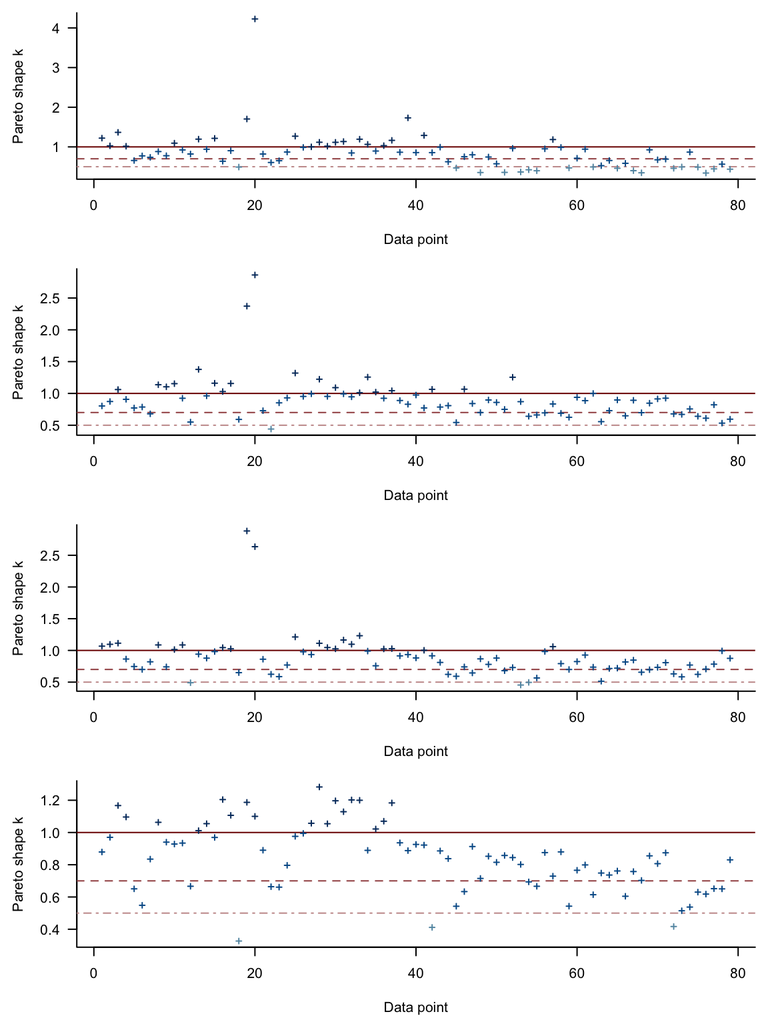

```r
par(mfrow=c(4,1), mai=c(0.6,0.6,0.1,0.1), omi=rep(0,4))
LOO_both <- LOO_age <- LOO_esc <- vector("list", n_mods)
## extract log densities from JAGS objects
for(i in 1:n_mods) {
  ## convert mcmc.list to matrix
  tmp_lp <- as.matrix(mod_fits[[i]])
  ## extract pointwise likelihoods
  tmp_lp <- tmp_lp[,grepl("lp_", colnames(tmp_lp))]
  ## if numerical underflows, convert -Inf to 5% less than min(likelihood)
  if(any(is.infinite(tmp_lp))) {
    tmp_lp[is.infinite(tmp_lp)] <- NA
    tmp_min <- min(tmp_lp, na.rm = TRUE)
    tmp_lp[is.na(tmp_lp)] <- tmp_min * 1.05
  }
  ## calculate LOOIC
  LOO_both[[i]] <- loo(tmp_lp)
  plot(LOO_both[[i]], main="")
  LOO_age[[i]] <- loo(tmp_lp[,grep("age",colnames(tmp_lp))])
  LOO_esc[[i]] <- loo(tmp_lp[,grep("esc",colnames(tmp_lp))])
}
```

```r
## LOOIC for all data
tbl_LOO_both <- round(compare(x = LOO_both), 2)
rownames(tbl_LOO_both) <- sub("model", "", rownames(tbl_LOO_both))
tbl_LOO_both <- tbl_LOO_both[order(as.numeric(rownames(tbl_LOO_both))), ]
tbl_LOO_both <- cbind(model = rep(c("Ricker","B-H"),2),
                      covar = rep(c("No","Yes"),ea=2),
                      as.data.frame(tbl_LOO_both))
tbl_LOO_both[order(tbl_LOO_both[,"looic"]), ]
```

```
##    model covar elpd_diff elpd_loo se_elpd_loo  p_loo se_p_loo  looic se_looic
## 4    B-H   Yes      0.00  -379.21       48.16 136.66     9.63 758.42    96.32
## 2    B-H    No     -5.98  -385.19       50.09 153.59    14.34 770.39   100.18
## 3 Ricker   Yes    -19.13  -398.34       48.63 148.66    15.19 796.68    97.25
## 1 Ricker    No    -24.06  -403.27       50.83 159.91    19.85 806.53   101.66
```

```r
## LOOIC for all data (pairwise)
## `elpd_diff` will be pos (neg) if the expected predictive accuracy for the second (first) model is higher.
## Ricker without vs with covariates
compare(LOO_both[[1]], LOO_both[[3]])
```

```
## elpd_diff        se
##       4.9      11.7
```

```r
## BH without vs with covariates
compare(LOO_both[[2]], LOO_both[[4]])
```

```
## elpd_diff        se
##       6.0      10.3
```

```r
## Ricker to BH (without covariates)
compare(LOO_both[[1]], LOO_both[[2]])
```

```
## elpd_diff        se
##      18.1       9.6
```

```r
## Ricker to BH (with covariates)
compare(LOO_both[[3]], LOO_both[[4]])
```

```
## elpd_diff        se
##      19.1      10.8
```

```r
## LOOIC for age data only
tbl_LOO_age <- round(compare(x = LOO_age), 2)
rownames(tbl_LOO_age) <- sub("model", "", rownames(tbl_LOO_age))
tbl_LOO_age <- tbl_LOO_age[order(as.numeric(rownames(tbl_LOO_age))), ]
tbl_LOO_age <- cbind(model = rep(c("Ricker","B-H"),2),
                     covar = rep(c("No","Yes"),ea=2),
                     as.data.frame(tbl_LOO_age))
tbl_LOO_age[order(tbl_LOO_age[,"looic"]), ]
```

```
##    model covar elpd_diff elpd_loo se_elpd_loo  p_loo se_p_loo  looic se_looic
## 4    B-H   Yes      0.00  -370.66       22.37  99.35     5.54 741.32    44.73
## 3 Ricker   Yes    -12.80  -383.46       21.77 112.25    11.93 766.92    43.53
## 2    B-H    No    -13.13  -383.79       22.07 112.46    11.25 767.57    44.14
## 1 Ricker    No    -18.69  -389.34       24.68 117.97    17.04 778.69    49.36
```

```r
## LOOIC for escapement data only
tbl_LOO_esc <- round(compare(x = LOO_esc), 2)
rownames(tbl_LOO_esc) <- sub("model", "", rownames(tbl_LOO_esc))
tbl_LOO_esc <- tbl_LOO_esc[order(as.numeric(rownames(tbl_LOO_esc))), ]
tbl_LOO_esc <- cbind(model = rep(c("Ricker","B-H"),2),
                     covar = rep(c("No","Yes"),ea=2),
                     as.data.frame(tbl_LOO_esc))
tbl_LOO_esc[order(tbl_LOO_esc[,"looic"]), ]
```

```
##    model covar elpd_diff elpd_loo se_elpd_loo p_loo se_p_loo looic se_looic
## 2    B-H    No      0.00    -1.41        2.31 41.13     2.08  2.81     4.62
## 4    B-H   Yes     -7.14    -8.55        2.48 37.31     2.15 17.10     4.96
## 1 Ricker    No    -12.51   -13.92        4.80 41.94     4.63 27.84     9.59
## 3 Ricker   Yes    -13.47   -14.88        2.68 36.42     2.28 29.76     5.36
```

## 8.1 Distribution of pointwise likelihoods

At the moment this is for the Beverton-Holt model with covariates.

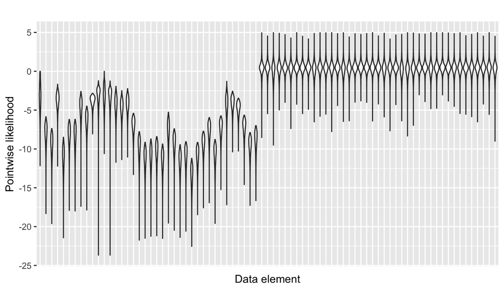

```r
## base plot
tidy_lp <- tidyr::gather(data.frame(tmp_lp), key = time, value = lp)
pp <- ggplot(tidy_lp, aes(x=time, y=lp)) +
  labs(title = "", x = "Data element", y = "Pointwise likelihood") +
  theme(axis.text.x = element_blank(),
        axis.ticks.x = element_blank())
## violin plot
p1 <- pp + geom_violin()
p1
```

## 8.2 Model diagnostics

```r
best_fit <- mod_fits[[4]]
## params of interest
par_conv <- c("alpha","beta",paste0("gamma[",seq(4),"]"),
              "sigma_r","sigma_s","pi_tau",paste0("pi_eta[",seq(A-1),"]"))
## Gelman-Rubin
gelman.diag(best_fit[,par_conv])
```

```
## Potential scale reduction factors:
##
##           Point est. Upper C.I.
## alpha           1.01       1.02
## beta            1.01       1.02
## gamma[1]        1.00       1.00
## gamma[2]        1.00       1.00
## gamma[3]        1.00       1.00
## gamma[4]        1.00       1.00
## sigma_r         1.00       1.00
## sigma_s         1.01       1.01
## pi_tau          1.01       1.04
## pi_eta[1]       1.00       1.01
## pi_eta[2]       1.00       1.00
## pi_eta[3]       1.00       1.00
## pi_eta[4]       1.00       1.00
## pi_eta[5]       1.00       1.01
##
## Multivariate psrf
##
## 1.16
```

```r
## Autocorrelation
t(round(autocorr.diag(best_fit[,par_conv],
                      lags = seq(mcmc_ctrl$thin, 4*mcmc_ctrl$thin, mcmc_ctrl$thin),
                      relative=FALSE), 2))
```

```
##           Lag 400 Lag 800 Lag 1200 Lag 1600
## alpha        0.40    0.18     0.09     0.07
## beta         0.40    0.18     0.08     0.07
## gamma[1]    -0.02    0.01    -0.02    -0.02
## gamma[2]    -0.01   -0.02     0.02    -0.02
## gamma[3]     0.03    0.03     0.02     0.00
## gamma[4]    -0.02   -0.01    -0.01     0.00
## sigma_r     -0.01    0.00     0.01    -0.02
## sigma_s      0.07    0.03     0.02     0.03
## pi_tau       0.13    0.08     0.08     0.07
## pi_eta[1]    0.25    0.15     0.11     0.07
## pi_eta[2]    0.01    0.00     0.02    -0.01
## pi_eta[3]    0.00   -0.01     0.01     0.00
## pi_eta[4]    0.01   -0.01     0.00     0.02
## pi_eta[5]    0.14    0.08     0.04     0.05
```

These diagnostics look pretty good, so we’ll save the output for this model.

```r
save(best_fit, file = file.path(analdir, "best_fit.rda"))
```